# Final Project; Categorical Data Analysis

Abby Smith, Miruna B., Martha Eichlersmith

11/10/2019

# Estimates of Killing in Casanare

Casanare is a large, rural state in Colombia that includes 19 municipalities and a population of almost 300,000 inhabitants. Located in the foothills of the Andes, Casanare has a history of violence. Multiple armed groups have operated in Casanare including paramilitaries, guerillas and the Colombian military. Many Casanare citizens have suffered violent deaths and disappearances.

But *how many* people have been killed or disappeared? We review the Human Rights Data Analysis Group (HRDAG)’s reporting on this work. In this study, the authors used information about victims of killings and disappearances provided by 15 datasets. The datasets come from state agencies – including government, security, forensic and judicial bodies – and from civil society organizations. Across these 15 datasets, there are individuals that have been “captured” only by one dataset, and some that have been captured by multiple. How can we disambguiate the patterns of violence?

# Multiple Systems Estimation (MSE), Capture Re-Capture

MSE estimates the total number of disappearances by comparing the size of the overlap(s) between lists to the sizes of the lists themselves. If the overlap is small, this implies that the population from which the lists were drawn is much larger than the lists. If, on the other hand, most of the cases on the lists overlap, this implies that the overall population is not much larger than the number of cases listed.

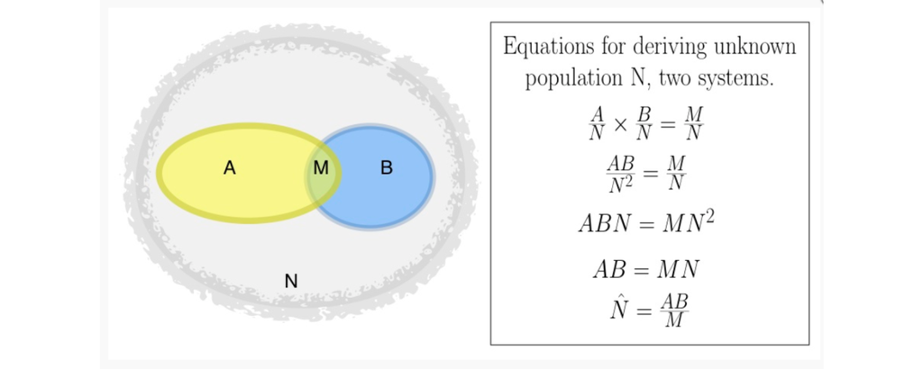

## MSE Assumptions

There are several MSE assumptions that are need for when there are two “systems” (lists), but not more than that. The assumptions are:

1. *Closed system*: The population of interest does not change during the measurement period. This means that the object of measurement, whether that is a population of persons in a country or a population of violent events that occurred in a state, is a closed system: the target population does not change during the period of measurement. This assumption is generally unproblematic for data on violent events, because events that occurred cannot “un-occur” later.
2. *Perfect matching (record linkage!)*: The overlap between systems (i.e., the group of cases recorded in more than one list) is perfectly identified.
3. *Equal probability of capture*: For every data system, each individual has an equal probability of being captured. For example, every death has probability X of being recorded in list 1, every death has probability Y of being recorded in list 2, and so on. TThis assumption, the homogeneity of capture probability, is unlikely to hold for any type of violence data. For example, persons with fewer social connections may be both more likely to go missing and less likely to be reportedmissing; rural locations are more difficult to access than urban ones. Constructing two-sample estimates without accounting for different probabilities of capture leads to conclusions that may be biased.
4. *Independence of lists*: Capture in one list does not affect probability of capture in another list. For example, being reported to one NGO does not change the probability that an individual is reported to another. The third assumption, independence of systems, is similarly difficult to meet.

Like differences in capture probability, dependences between systems are impossible to account for in the the two-system setting. A common example here is the difference between governmental and non-governmental organizations. Because different populations may have different levels of trust in the two organizations, reporting to one type of organization may imply that the witness is very unlikely to report to the other.

# Overview of Data

## Different Datasets - Different Stories

We motivate our need for a more sophisticated analysis by showing the reporting patterns of 3 different organizations across 1998-2007. If we relied on just one organization or even a combination of two we could tell differnt stories regarding the violence. Relying on FAM shows a peak in violent incidents in 2003, while reports by IMLM show a peak in 2004 . Using multiple systems estimation allows us to parse both the reported and unreported violent in Casanare.

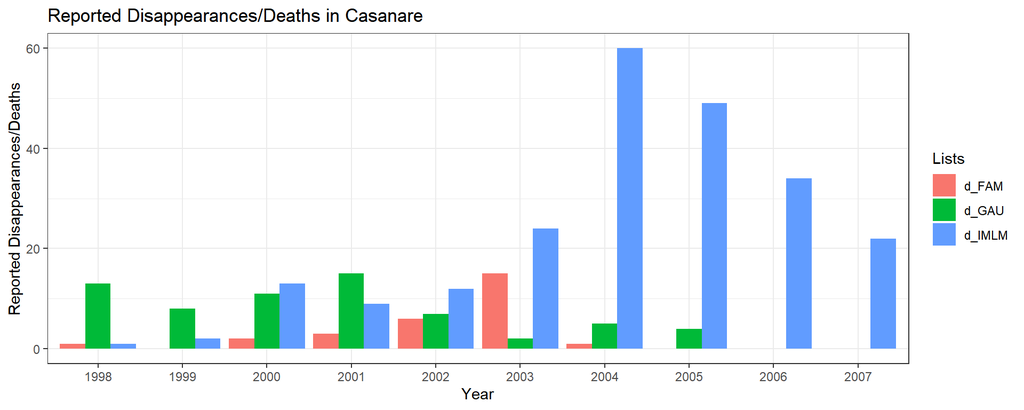

## Heterogenity

From the bottom graph of our heterogenity graph, we see differences in the capture probabilities across lists.

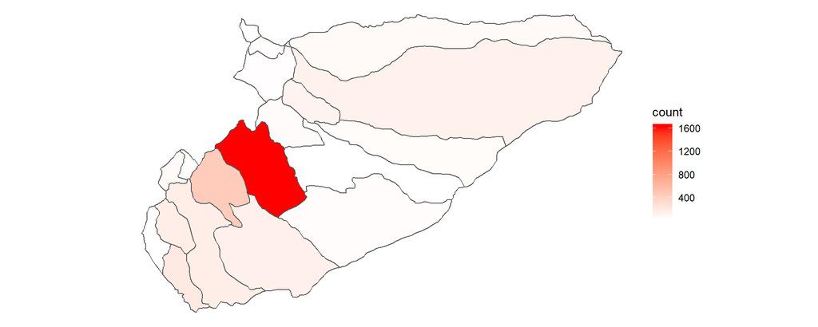

## Total Reported Victims Trends

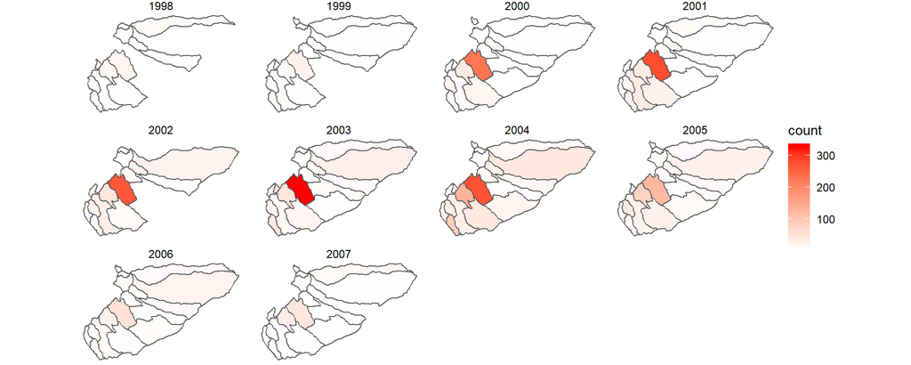

# Loglinear Modelling

We will describe the model as if we had two datasets (for simplicity).

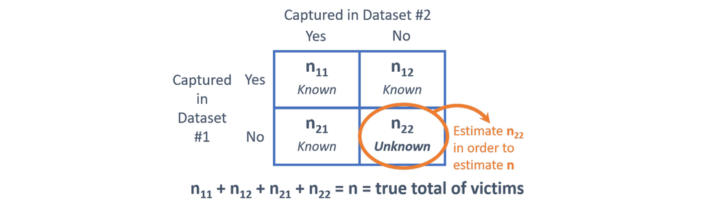

Let’s further say that the number of violent incidents selected into a list or combination of lists is $m_{100}$, $m_{010}$, $m_{001}$,$m_{110}$, $m_{101}$, $m_{001}$, and $m_{111}$.

Each of these cells is a count of cases. For example, $m_{100}$,is the number of cases in only list 1; $m_{110}$, is the number of cases that appear in lists 1 and 2, but not list 3—and so on.

$$\log(m_{000}) = a + \beta_1(m_{100}) + \beta_2(m{010}) + \beta_3(m_{001}) + \beta_{12}(m_{110}) + \beta_{13}(m_{101}) + \beta_{23}(m_{011})$$

This is the saturated form of the log-linear models introduced in Bishop, Fienberg and Holland (1975). To quote from Agresti, “the saturated GLM has a separate parameter for each observation. It gives a perfect fit. This sounds good, but it is not a helpful model. It does not smooth the data or have the advantages that a simpler model has, such as parsimony. Nonetheless, it serves as a baseline for other models, such as for checking model fit.”

When estimation of the total “population” of missing people in Casanare is the goal (as it typically is with multiple-systems estimation), the key value here is the intercept $a$. To estimate $\log(m_{000}$), all the other $m$ values are zero. Therefore the only term that contributes to the estimate of $\log(m_{000}$) is a. The value of $m_{000}$ is therefore the exponentiated value of $a$, that is, $\exp(a)$. The total number of cases is the sum of the observed cases (that is, the seven values of $m$) plus $\exp(a)$.

As with any regression and data mining model, we want to avoid overfitting. There is a tradeoff we need to balance between “goodness of fit”, and simple (parsimonious) models.

We need to find the best model in order to get an accurate estimate of $a$. Thus, we should determine whether the full (saturated) model above, which assumes that all three two-way interactions between datasets are important, is actually necessary. There are three simpler models that assume only one two-way interaction.

$$\log(m_{000}) = a + \beta_1(m_{100}) + \beta_2(m_{010}) + \beta_3(m_{001}) + \beta_{12}(m_{110})$$

$$\log(m_{000}) = a + \beta_1(m_{100}) + \beta_2(m_{010}) + \beta_3(m_{001}) + \beta_{13}(m_{101})$$

$$\log(m_{000}) = a + \beta_1(m_{100}) + \beta_2(m_{010}) + \beta_3(m_{001}) + \beta_{23}(m_{011})$$

$$\log \left(m_{000}\right)=a+\beta_{1}\left(m_{100}\right)+\beta_{2}\left(m_{010}\right)+\beta_{3}\left(m_{001}\right)+\beta_{12}\left(m_{110}\right)+\beta_{13}\left(m_{101}\right)$$

$$\log \left(m_{000}\right)=a+\beta_{1}\left(m_{100}\right)+\beta_{2}\left(m_{010}\right)+\beta_{3}\left(m_{001}\right)+\beta_{12}\left(m_{110}\right)+\beta_{23}\left(m_{011}\right)$$

$$\log \left(m_{000}\right)=a+\beta_{1}\left(m_{100}\right)+\beta_{2}\left(m_{010}\right)+\beta_{3}\left(m_{001}\right)+\beta_{13}\left(m_{101}\right)+\beta_{23}\left(m_{011}\right)$$

In this case, we can clearly write out the seven possible models, when we model selection into three datasets, we estimate all seven of these, and choose the model that minimizes the Bayesian Information Criterion (BIC), a test that weighs goodness of fit against degrees of freedom.

# Challenges with Loglinear models

- Interpretation: The inclusion of so many variables in loglinear models often makes interpretation very difficult.
- Independence: The frequency in each cell is independent of frequencies in all other cells, which is not necessarily the case here. We attempt to model this.
- Adequate Sample Size: With loglinear models, you need to have at least 5 times the number of cases as cells in your data. For example, if you have a 2x2x3 table, then you need to have 60 cases. If you do not have the required amount of cases, then you need to increase the sample size or eliminate one or more of the variables.

# Choosing our “Systems”

Our dataset encompasses 15 lists, far too many to model with a loglinear model. We collapse our 15 lists into 4 systems,

| security_ind | forensic_ind | judicial_ind | civil_ind | Freq |
| --- | --- | --- | --- | --- |
| 0 | 0 | 0 | 1 | 5 |
| 0 | 0 | 1 | 0 | 1 |
| 0 | 0 | 1 | 0 | 1 |
| 1 | 0 | 0 | 0 | 1 |
| 1 | 0 | 1 | 0 | 1 |
| 0 | 0 | 1 | 1 | 1 |

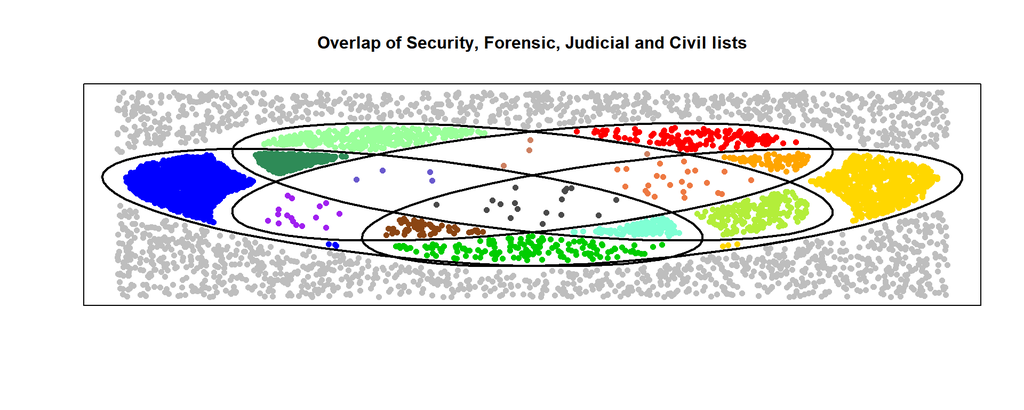

# Results of Loglinear Modelling

We will need the hierchachal structure to perform model selection. It’s important to note that a model is not chosen if it bears no resemblance to the observed data. The choice of a preferred model is typically based on a formal comparison of goodness-of-fit statistics associated with models that are related hierarchically (models containing higher order terms also implicitly include all lower order terms). Ultimately, the preferred model should distinguish between the pattern of the variables in the data and sampling variability, thus providing an intuitive interpretation.

```
##
## Number of captured units: 3501
##
## Abundance estimations and model fits:
##               abundance stderr deviance df      AIC      BIC infoFit
## M0               5604.9  100.6 2279.471 13 2376.736 2389.057      OK
## Mt               5232.8   87.3  529.823 10  633.087  663.891      OK
## Mh Chao (LB)     5970.7  139.9 2253.979 12 2353.244 2371.726      OK
## Mh Poisson2      6147.5  188.4 2262.122 12 2361.387 2379.869      OK
## Mh Darroch       6866.5  367.9 2257.937 12 2357.202 2375.684      OK
## Mh Gamma3.5      7725.1  634.4 2256.636 12 2355.901 2374.383      OK
## Mth Chao (LB)    5665.3  125.1  473.765  8  581.029  624.155      OK
## Mth Poisson2     6035.0  181.7  482.267  9  587.532  624.497      OK
## Mth Darroch      7204.7  411.3  476.057  9  581.322  618.287      OK
## Mth Gamma3.5     8782.7  810.7  474.715  9  579.980  616.945      OK
## Mb               4228.2   64.7 2107.184 12 2206.448 2224.931      OK
## Mbh              3643.0   47.7 1618.987 11 1720.252 1744.895      OK
```

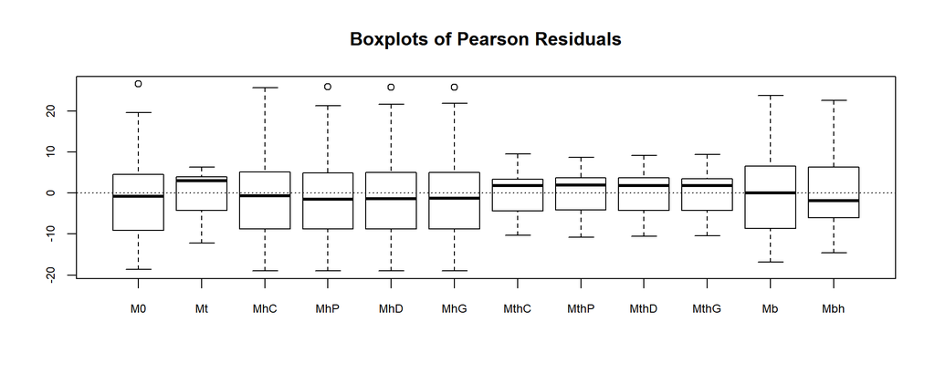

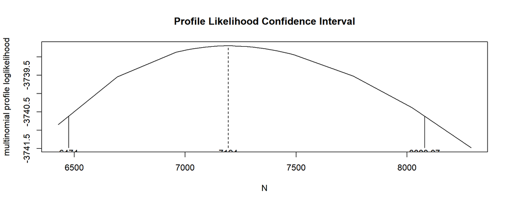

[output not shown]

The “number of captured units” is the number of observed elements, in this example, the number of people documented as missing/killed, we usually call this $N_k$. The “abundance” column shows the estimate of $\hat{N_k}$, the total population including the observed and the estimated unobserved deaths. The AIC and BIC columns show the “information coefficients” which balance the goodness of fit (shown in the “deviance” column) with the information used to estimate the model (degrees of freedom indicate this).

Each model controls for a subset of all the possible interactions among the models. In the context of MSE, the two- and three-way interactions estimate (and to some extent, control for) associations in the probabilities of capture between (and among) the lists. For example, is a certain person more likely to be seen on one list, and also more likely to be seen on a second list? If associations like this are present (and they usually are), they can bias the estimate.

We display some basic capture-recapture frequency statistics to explore capture patterns. It displays, for $i= 1,...t$, the number of people captured $i$ times ($f_i$), the number of people captured for the first time on occasion $i$ ($u_i$), the number of units capturedfor the last time on occasion $i$ ($v_i$) and the number of units captured on occasion $i$ ($n_i$). If the $n_i$ statistics vary among capture occasions, there is a temporal effect– which we clearly see here. We would expect the top panel of the plot to be linear, while the bottom panel should be concave down or exhibit no pattern for capture patterns that are best fit with $M_{th}$ models.

```
##
## Number of captured units: 3501
##
## Frequency statistics:
##        fi    ui    vi    ni
## i = 1  2392  1128   317  1128
## i = 2   866  1455  1640  2028
## i = 3   225   785  1216  1387
## i = 4    18   133   328   328
## fi: number of units captured i times
## ui: number of units captured for the first time on occasion i
## vi: number of units captured for the last time on occasion i
## ni: number of units captured on occasion i
```

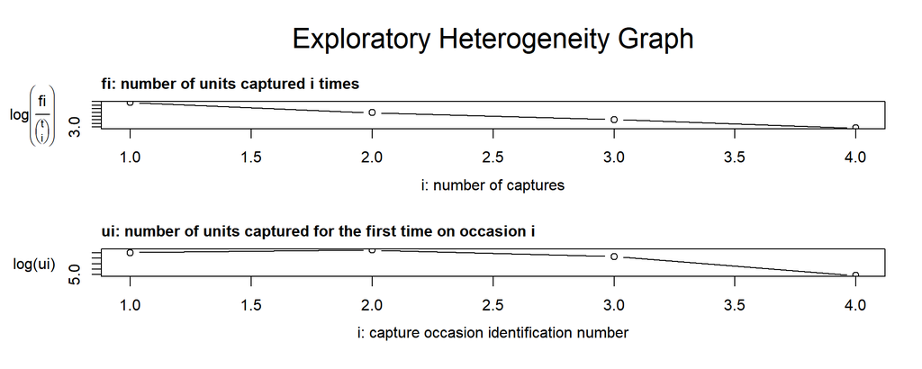

$$\log(\frac{f_i}{{t \choose i}}) = \log (\frac{N \times P(i \text{ captures})}{{t \choose i}}) = \log(N(1-p)^{t-i} p^i = \log(N(1-p)^t) + i\log(\frac{p}{1-p})$$